# Homework 6

Yiming Gao (NetID: yimingg2)

2017/3/17

# Exercise 1

Do the following:

- Set a seed value equal to your UIN
- Test-train split the data using approximately 50% of the data for training.
- Report 5 fold cross-validated, train, and test accuracy for each of the three models
  - You should arrange this in a table
  - **You do not need to cross-validate the selection method, but rather only cross-validate the resulting model**

```r
# create data
library(readr)
library(class)
library(MASS)
library(ggplot2)
library(caret)
library(leaps)

data = read_csv("hw06-data.csv")
uin = 650379994
set.seed(uin)
# train-test split
train_index = createDataPartition(data$y, p = 0.5, list = FALSE)
train_data = data[train_index, ]
test_data = data[-train_index, ]
```

- Fit three models:
  - Additive logistic regression
  - Logistic regression with predictors chosen using a variable selection technique of your choice
  - $k$-nearest neighbors using a well tuned value of $k$

## Additive Logistic Regression

```r
# Some functions
accuracy <- function(actual, predicted) {
  mean(actual == predicted)
}

get_pred = function(mod, data, res = "y", pos = 1, neg = 0, cut = 0.5) {
  probs = predict(mod, newdata = data, type = "response")
  ifelse(probs > cut, pos, neg)
}

# convert response to factor
train_data$y = factor(train_data$y)
test_data$y = factor(test_data$y)

# additive logistic regression
add = train(
  form = y ~ ., data = train_data, method = "glm", family = "binomial",
  trControl = trainControl(method = "cv", number = 5)
)

# train acc
add_train_acc = accuracy(actual = train_data$y,
                         predicted = predict(add, newdata = train_data))
# test acc
add_test_acc = accuracy(actual = test_data$y,
                        predicted = predict(add, newdata = test_data))
```

## Reduced Logistic Regression

I use `step` function in `leaps` package to perform stepwise variable selection.

```r
# variable selection
add1 = glm(y~., data = train_data, family = "binomial")
step = step(add1, trace = 0)
# coefficients and AIC value
step$coefficients
```

```
## (Intercept)         x01         x02         x04         x06         x07
##  0.48323928  2.99478108 -2.04209296 -0.08733422  1.07993776  1.17428424
```

```r
step$aic
```

```
## [1] 713.774
```

The stepwise variable selection gives five predictors: x01, x02, x04, x06 and x07, with $AIC=713.774$. Then we calculate the corresponding 5 fold cross-validated, train and test accuracy.

```r
reduced = train(
  form = y ~ x01 + x02 + x04 + x06 + x07, data = train_data, method = "glm", family = "binomial", trControl = trainControl(method = "cv", number = 5))

# train acc
reduced_train_acc = accuracy(actual = train_data$y, predicted = predict(reduced, newdata = train_data))
# test acc
reduced_test_acc = accuracy(actual = test_data$y, predicted = predict(reduced, newdata = test_data))

c(reduced_train_acc, reduced_test_acc)
```

```
## [1] 0.8784 0.8856
```

## K-nearest neighbors

First we tune $k$ from 1 to 501 by 5. It may take 10 seconds to run the code.

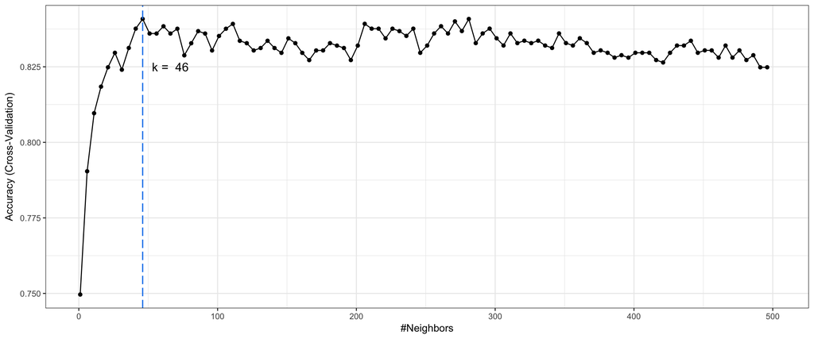

```r
knn = train(y ~ ., data = train_data, method = "knn",
  trControl = trainControl(method = "cv", number = 5),
  preProcess = c("center", "scale"),
  tuneGrid = expand.grid(k = seq(1, 501, by = 5)))

best_k = knn$bestTune$k

# plot the model
ggplot(knn) + theme_bw() + geom_vline(xintercept = best_k, colour = "dodgerblue2", size = 0.6, linetype = "longdash") + annotate("text", x = best_k + 20, y = 0.825, label = paste("k = ", best_k), cex = 4.5)
```

From the plot, we can notice that after reaching the highest cross-validation accuracy after best k, the accuracy has a slow decreasing trend as number of neighbors grows to 500, which demonstrates that we’ve considered enough values of k.

Then we tune k from 1 to 100 by 1, and compute the 5 fold cross-validated, train and test accuracy corresponding to `best_k`.

```r
knn = train(y ~ ., data = train_data, method = "knn",
  trControl = trainControl(method = "cv", number = 5),
  preProcess = c("center", "scale"),
  tuneGrid = expand.grid(k = seq(1, 100, by = 1)))

best_k = knn$bestTune$k

# train accuracy
knn_train_acc = accuracy(actual = train_data$y, predicted = predict(knn, newdata = train_data))

# test accuracy
knn_test_acc = accuracy(actual = test_data$y, predicted = predict(knn, newdata = test_data))
```

We summarize the results into following table:

| Model | Train accuracy | Test accuracy |
| --- | --- | --- |
| Additive Logistic Regression | 0.884 | 0.8832 |
| Reduced Logistic Regression | 0.8784 | 0.8856 |
| k-nearest neighbors (k = 61) | 0.8408 | 0.8456 |

- What is the model you chose via selection?

Based on AIC criterion, the reduced model via selection is `y ~ x01 + x02 + x04 + x06 + x07`.

- Plot the cross-validated $k$-nearest neighbor results. Argue that this plot verifies that you have considered enough values of $k$.

From the plot, we can notice that after reaching the highest cross-validation accuracy after best k, the accuracy has a slow decreasing trend as number of neighbors grows to 500, which demonstrates that we’ve considered enough values of k.

- What value of $k$ did you select?

I select k = 61.

- Based on these results, which model do you prefer?

I prefer **reduced logistic model**. Beacuse it gives similar train and test accuracy as additive logistic model, of which there is no overfitting problem. And it only contains 5 predictors, which is much simpler than the additive one.

# Exercise 2

We first read in the data and do some transformations.

```r
library(readr)
leukemia = read_csv("leukemia.csv", progress = FALSE)
# large dataset, remember to use 5-fold cross-validation
```

```r
library(glmnet)
y = as.factor(leukemia$class)
X = as.matrix(leukemia[, -1])
```

- Fit an logistic regression with a lasso penalty without using cross-validation.

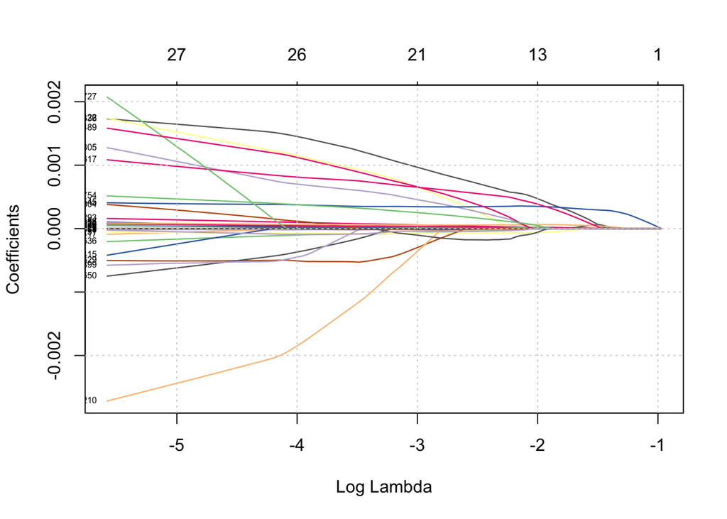

```r
library(ggplot2)
library(RColorBrewer)
fit_lasso = glmnet(X, y, alpha = 1, family = "binomial") # logistic with lasso
plot(fit_lasso, xvar = "lambda", label = TRUE, col = brewer.pal(19, "Accent"), lwd = 1.2)
grid()
```

- Use cross-validation to tune an logistic regression with a lasso penalty.

Since `cv.glmnet()` doesn’t calculate prediction accuracy for classification, we take the $lambda$ values and create a grid to search in order to obtain prediction accuracy.

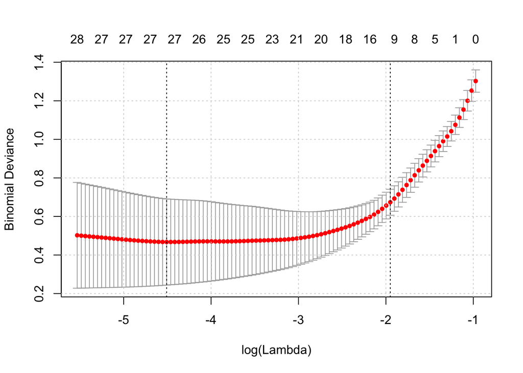

```r
fit_lasso_cv = cv.glmnet(X, y, alpha = 1, family = "binomial")
lasso_min = fit_lasso_cv$lambda.min
lasso_1se = fit_lasso_cv$lambda.1se
plot(fit_lasso_cv)
grid()
```

```r
# train() function in caret package
cv_5 = trainControl(method = "cv", number = 5)
lasso_grid = expand.grid(alpha = 1, lambda = c(lasso_min, lasso_1se))

fit_lasso = train(
  x = X,
  y = y,
  method = "glmnet",
  trControl = cv_5,
  tuneGrid = lasso_grid
)

lasso_acc = round(fit_lasso$results$Accuracy, 4)
lasso_acc_sd = round(fit_lasso$results$AccuracySD, 4)
lasso_acc
```

```
## [1] 0.9295 0.9019
```

- Fit an logistic regression with ridge penalty without using cross-validation.

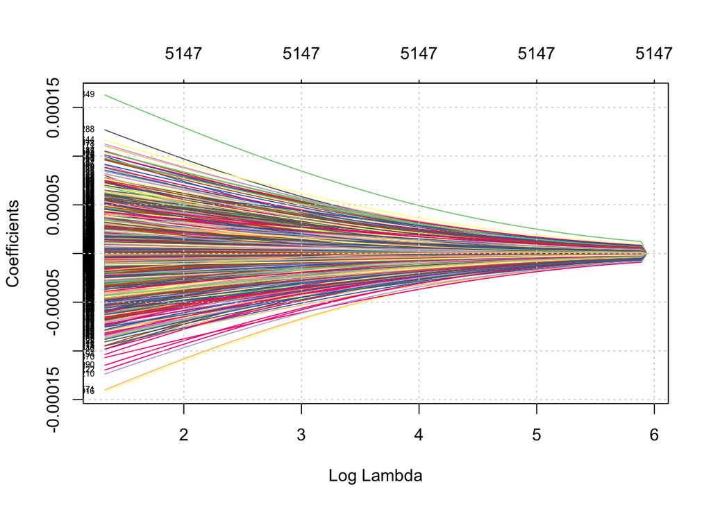

```r
fit_ridge = glmnet(X, y, alpha = 0, family = "binomial") # logistic with ridge
plot(fit_ridge, xvar = "lambda", label = TRUE, col = brewer.pal(19, "Accent"))
grid()
```

- Use cross-validation to tune an logistic regression with a ridge penalty.

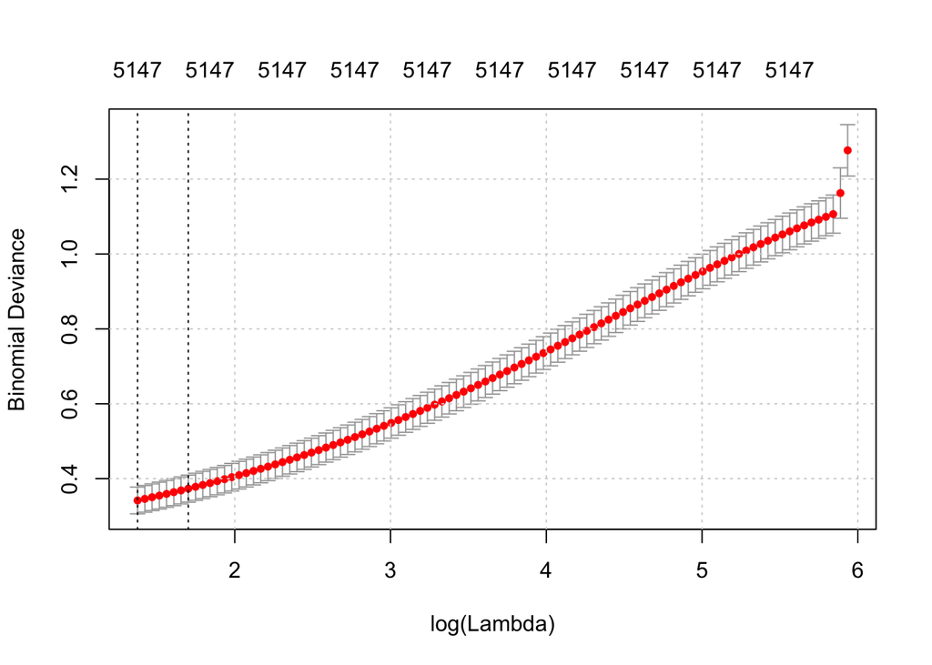

```r
fit_ridge_cv = cv.glmnet(X, y, alpha = 0, family = "binomial")
ridge_min = fit_ridge_cv$lambda.min
ridge_1se = fit_ridge_cv$lambda.1se
plot(fit_ridge_cv)
grid()
```

```r
# train() function in caret package
cv_5 = trainControl(method = "cv", number = 5)
ridge_grid = expand.grid(alpha = 0, lambda = c(ridge_min, ridge_1se))

fit_ridge = train(
  x = X,
  y = y,
  method = "glmnet",
  trControl = cv_5,
  tuneGrid = ridge_grid
)

ridge_acc = round(fit_ridge$results$Accuracy, 4)
ridge_acc_sd = round(fit_ridge$results$AccuracySD, 4)
ridge_acc
```

```
## [1] 0.9857 0.9857
```

- Use cross-validation to tune $k$-nearest neighbors using `train()` in `caret`.

```r
fit_knn = train(
  class ~ .,
  data = leukemia,
  method = "knn",
  trControl = cv_5
)

knn_acc = round(fit_knn$results[c("k", "Accuracy")], 4)
knn_acc_sd = round(fit_knn$results[c("k", "AccuracySD")], 4)
knn_acc
```

```
##   k Accuracy
## 1 5   0.9305
## 2 7   0.8886
## 3 9   0.8867
```

```r
# q1
nrow = nrow(leukemia) # 72
ncol = ncol(leukemia) # 5148
```

- How many observations are in the dataset? How many predictors are in the dataset?

- Based on the deviance plot, do you feel that `glmnet` considered enough $\lambda$ values for lasso? For ridge?

- How does $k$-nearest neighbor compare to the penalized methods? Can you explain any difference?

KNN is a **non-parametric** method used for classification and regression that in order to determine the classification of a point, combines the classification of the k nearest points. However, both lasso and ridge are **parametric** methods which are good at handling multicollinearity, i.e., a predictor matrix with rank less than the number of its columns.

- Summarize these **seven** models in a table. (Two lasso, two ridge, three knn.) For each report the cross-validated accuracy and the standard deviation of the accuracy.

| Model | Cross-validated accuracy | Std of accuracy |
| --- | --- | --- |
| Lasso with `lambda.min` | 0.9295 | 0.0506 |
| Lasso with `lambda.1se` | 0.9019 | 0.0409 |
| Ridge with `lambda.min` | 0.9857 | 0.0319 |
| Ridge with `lambda.1se` | 0.9857 | 0.0319 |
| 5-nearest neighbors | 0.9305 | 0.0026 |
| 7-nearest neighbors | 0.8886 | 0.0638 |
| 9-nearest neighbors | 0.8867 | 0.0964 |

- Based on your results, which model would you choose?